# USCOTS In-class Assignment

Your Name Here

## Data Description

Data was collected from the 2019 United States Census Bureau American Community Survey (ACS), the 2017 FBI Uniform Crime Reporting database (UCR), unemployment numbers from the Bureau of Labor Statistics, mask wearing survey data from the New York Times, and COVID-19 Coronavirus cases and deaths (from USA Facts, a not-for-profit nonpartisan civic initiative providing government data) for each county/parish in the United States and Washington, D.C. Below is a list of some variables to be used in this assignment.

- `countyFIPS` - The five character numeric FIPS code uniquely identifying the county
- `CountyName` - The name of the county/parish
- `State` - The two character abbreviation for the State
- `stateFIPS` - The two character numeric FIPS code uniquely identifying each state
- `Area` - The geographic area of the county, in squared miles
- `Total_cases` - The total number of COVID-19 cases reported for the county as of 07 November 2020
- `Total_deaths` - The total number of COVID-19 related deaths reported for the county as of 07 November 2020
- `pop` - The estimated population for the county in the year 2019
- `age` - The median age of county residents, estimated in the year 2019
- `PercCollege` - The percentage of residents in the county with a college degree (Associates or higher), estimated in 2019
- `PercVets` - The percentage of residents in the county that are veterans of the US armed forces, estimated in 2019
- `Unemployment_rate` - The estimated county-level unemployment rate in November 2020 (seasonally unadjusted)
- `HighMaskUsage` - An estimate of the proportion of county residents who “always” or “mostly always” wear a mask while in public, based on a New York Times Survey in September 2020
- `violent_crime` - The total number of recorded violent crimes in 2018

Note: FIPS is the Federal Information Processing Standards mechanism for uniquely identifying states, counties and other regions.

**Do not edit the below code chunk.**

```r
data_web_file <- "https://raw.githubusercontent.com/tjfisher19/uscots2021_presentation/main/usCountyCoronaVirusData_uscots2020-11-07.csv"
raw_coronavirus_data <- read.csv(data_web_file)
```

## Goals for this assignment

#### Statistical Goals

The assignment for today is designed to give you practice at fitting linear models in R and performing some basic transformations on variables to see how you can potentially *improve* models.

This assignment also is designed to provide insight into the issue of confounding variables and stress an underlying message that **correlation is NOT causation**.

#### Contextual Goals

We will look at building a model to help explain COVID-19 related death rates across the contiguous United States. Please note that in STA 363 we attempt to use real and relevant datasets as much as possible. One of the main ideas from today is that a linear model from observational data does NOT lead to *causal* arguments about what variables cause more COVID-19 deaths, nor should any results today lead to broad conclusions about policy, politics, health or safety. We are only using a few of the variables in this large dataset and, like more real-world problems, the current situation is more complicated than the data provided. This data includes the latest COVID-19 counts as 07 November 2020 from the USA Facts website.

## PART 1

### Question 1

In the code chunk below, do the following:

- Create the following variables (giving contextually meaningful variable names):
  - The **Population Density**, defined as the population divided by the geographic area of the county.
  - The **Violent crime rate**, defined as the number of violent crimes per 1000 residents (`violent_crimes/pop*1000`).
  - The cumulative **COVID-19 death rate**, defined as the number of COVID-19 related deaths per 1000 residents as of 07 November 2020.
- Filter the data such that only counties with a recorded Coronavirus death in the contiguous United states are included; that is,
  - Remove records from the states Alaska (AK) and Hawaii (HI)
  - Remove counties with 0 deaths.
- Select the following variables for analysis:
  - Median age of the county
  - Population density
  - Percent of the population with a college degree
  - Percent of residents that are veterans of the US Armed Forces
  - The unemployment rate for November 2020
  - Violent crime rate
  - The estimated proportion of county residents who always, or almost always, wear a mask in public.
  - COVID-19 death rate
- Call this new dataset `county_data`.

```r
county_data <- raw_coronavirus_data %>%
   mutate(Pop_density = pop/Area,
          Violent_crime_rate = violent_crime/pop*1000,
          Corona_death_rate = Total_deaths/pop*1000) %>%
   filter(!State %in% c("AK", "HI"),
          Total_deaths > 0) %>%
   select(age, Pop_density, PercCollege, PercVets, Unemployment_rate, Violent_crime_rate, HighMaskUsage, Corona_death_rate)
```

### Question 2 - EDA

Build a scatterplot matrix of the processed data (result of question 1). Describe any systematic patterns you see in the relationships between variables. Also, comment on the supplied density plots along the diagonal for several of the variables’ distributions.

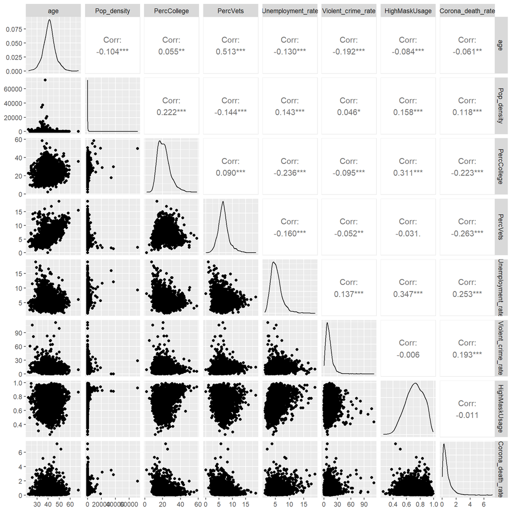

```r
ggpairs(county_data)
```

**It is difficult to determine many systematic patterns between the variables as (at least) three of the measurements are heavily right-skewed. In particular, the response variable is highly skewed, so we are likely to be violating some of the underlying assumptions for regression. Population density and violent crime rate are also right skewed, which could lead to nonlinearity in the model.**

### Question 3 - Initial Linear Model

Fit a linear regression where you model the county COVID-19 death rate as a function of the county’s median age, log base 10 of the population density, the percentage of residents that are veterans, the percentage with a college degree, log base 10 of the violent crime rate plus 1, the county-level unemployment rate and and estimated proportion of county residence who always, or mostly always, wear a mask when in public. Assess the underlying assumptions of this model.

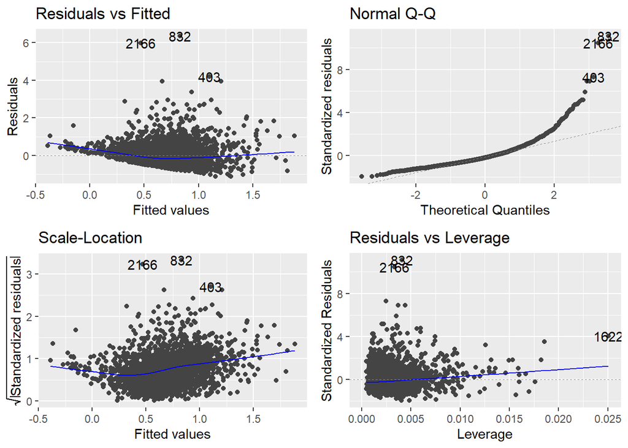

```r
fit_q3 <- lm(Corona_death_rate ~ age + log10(Pop_density) + PercVets + PercCollege +
                log10(Violent_crime_rate+1) + Unemployment_rate + HighMaskUsage, data=county_data)
autoplot(fit_q3)
```

**There are clear assumption violations. Based on the Residuals vs Fitted plot, we see a clear fanning appearance in the residuals. This, along with the increasing trend in the Scale-Location plot, suggests a violation of the constant variance assumption. The residuals are clearly non-normal with many standardized residuals exceeding the value of 5 (keep in mind these are $Z$-scores). There is also some slight curvature in the Residuals vs Fitted smoother, suggesting a potential violation of the underlying linearity assumption of the model.**

### Question 4 - Transformed linear regression

Fit a multiple regression where the **log 10 of the COVID-19 death rate** is modeled by the county’s median age, the log base 10 of the population density, the percentage of residents that are veterans, the percentage with a college degree, the log base 10 of the violent crime rate plus 1, the county-level unemployment rate and and estimated proportion of county residence who always, or mostly always, wear a mask when in public. Assess the underlying assumptions of this model.

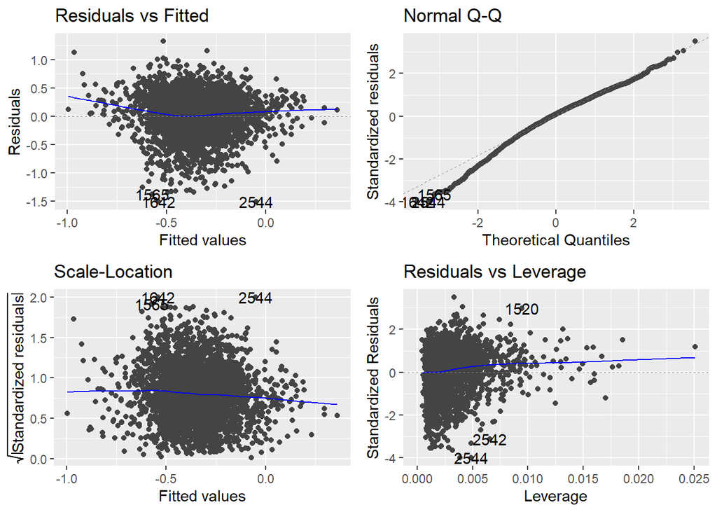

```r
fit_q4 <- lm(log10(Corona_death_rate) ~ age + log10(Pop_density) + PercVets + PercCollege +
                log10(Violent_crime_rate+1) + Unemployment_rate + HighMaskUsage, data=county_data)
autoplot(fit_q4)
```

**Overall things look pretty good. There are now no great concerns for non-normality or nonconstant variance. The strangeness in the Residuals vs Fitted plot is not very systematic and the Scale-Location looks good.**

## PART 2

### Question 5 - Prior belief

For the last 16+ months, the world has grappled with the SARS-CoV-2 virus. Based on all that you have heard, what do you expect to happen to the COVID-19 death rate as the median age in a county increases?

*NOTE: This question does not involve any data analysis, it is only asking you to express the belief based on your knowledge of the pandemic.*

**COVID-19 related mortality rates appear to be more prevalent in older people, so I would expect an older county to have a higher COVID-19 death rate.**

### Question 6 - Simple Linear Regression

Fit a simple linear regression modeling the **log base 10 COVID-19 related death rate** only as a function of the median age in the county. Provide the residual diagnostic plots (i.e., `autoplot`) and assess the underlying assumptions.

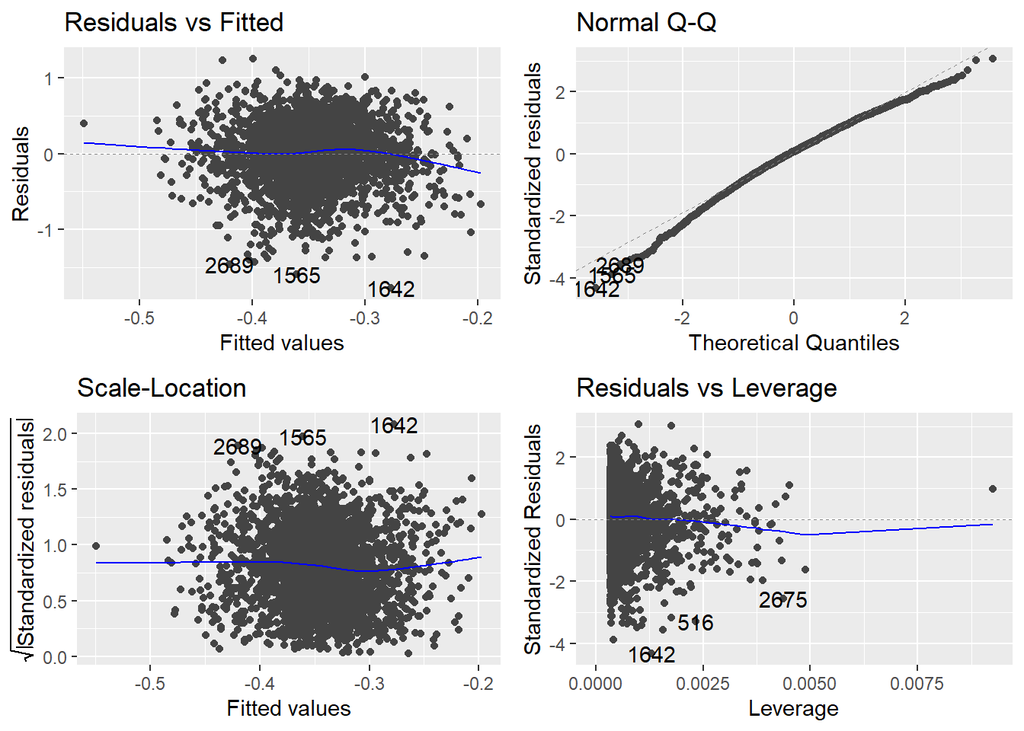

```r
fit_q6 <- lm(log10(Corona_death_rate) ~ age, data=county_data)
autoplot(fit_q6)
```

**Everything looks pretty reasonable here, especially compared to the previous model without the transformation.**

### Question 7 - Graph

Construct a scatterplot (some code to get you started is provided, note `eval=FALSE` in the Rmarkdown option) of the log base 10 of the COVID-19 related deaths as a function of a county’s median age. Include an overlaid regression line on the plot.

Based on the plotted fit, what do you notice about COVID-19 death rates as a function of age? Does this agree/disagree with your intuition in question 5? Discuss.

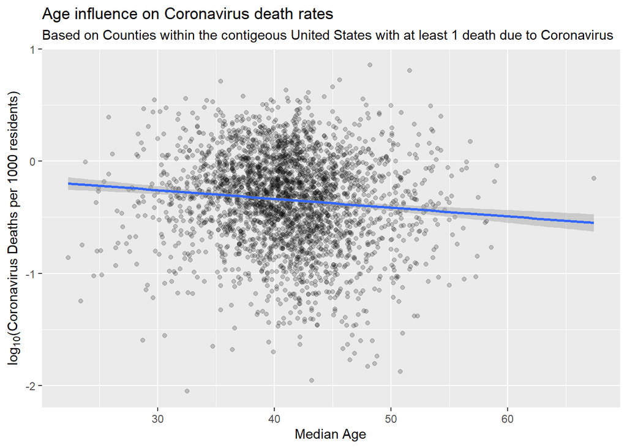

```r
ggplot(county_data, aes(x=age, y=log10(Corona_death_rate) ) ) +
  geom_point(alpha=0.2) +
  geom_smooth(method="lm") +
  labs(x="Median Age", y=expression(log[10]*"(Coronavirus Deaths per 1000 residents)"),
       title="Age influence on Coronavirus death rates",
       subtitle="Based on Counties within the contigeous United States with at least 1 death due to Coronavirus")
```

**Visually we see that the COVID-19 death rate appears to decrease as the age of a county increases. This appears to contradict our intuition based on all media reports!**

### Question 8 - Inference in simple linear regression

Provide the `summary()` and `confint()` output for your fitted model in question 6 and use it to address the following question: What does the interpretation of the slope coefficient suggest about the rate of COVID-19 related deaths as a function of a county’s median age? Relate this to question 5 and the plot in question 7.

```r
summary(fit_q6)
```

```
##
## Call:
## lm(formula = log10(Corona_death_rate) ~ age, data = county_data)
##
## Residuals:
##      Min       1Q   Median       3Q      Max
## -1.77526 -0.24918  0.02979  0.28377  1.25604
##
## Coefficients:
##              Estimate Std. Error t value Pr(>|t|)
## (Intercept) -0.023975   0.060836  -0.394    0.694
## age         -0.007792   0.001469  -5.306 1.21e-07 ***
## ---
## Signif. codes:  0 '***' 0.001 '**' 0.01 '*' 0.05 '.' 0.1 ' ' 1
##
## Residual standard error: 0.4095 on 2853 degrees of freedom
## Multiple R-squared:  0.009772,   Adjusted R-squared:  0.009424
## F-statistic: 28.15 on 1 and 2853 DF,  p-value: 1.207e-07
```

```r
confint(fit_q6)
```

```
##                   2.5 %      97.5 %
## (Intercept) -0.14326187  0.09531245
## age         -0.01067146 -0.00491248
```

**The coefficient is small in magnitude, but negative, -0.007792, suggesting that as the median age of a county increases, you would predict the number of COVID-19-related deaths to decrease. The 95% confidence interval is (-0.0106715, -0.0049125). The magnitude of this effect is not particularly strong, but we are performing our analysis on a log scale and this goes against our intuition.**

### Question 9 - Inference in multiple linear regression

```r
summary(fit_q4)
```

```
##
## Call:
## lm(formula = log10(Corona_death_rate) ~ age + log10(Pop_density) +
##     PercVets + PercCollege + log10(Violent_crime_rate + 1) +
##     Unemployment_rate + HighMaskUsage, data = county_data)
##
## Residuals:
##      Min       1Q   Median       3Q      Max
## -1.51214 -0.22085  0.03545  0.25342  1.32675
##
## Coefficients:
##                                Estimate Std. Error t value Pr(>|t|)
## (Intercept)                   -0.343037   0.082853  -4.140 3.57e-05 ***
## age                            0.008453   0.001702   4.968 7.18e-07 ***
## log10(Pop_density)             0.042987   0.012694   3.386 0.000718 ***
## PercVets                      -0.053547   0.004157 -12.882  < 2e-16 ***
## PercCollege                   -0.010474   0.001262  -8.297  < 2e-16 ***
## log10(Violent_crime_rate + 1)  0.187968   0.026427   7.113 1.43e-12 ***
## Unemployment_rate              0.029618   0.004073   7.271 4.59e-13 ***
## HighMaskUsage                 -0.265022   0.067667  -3.917 9.19e-05 ***
## ---
## Signif. codes:  0 '***' 0.001 '**' 0.01 '*' 0.05 '.' 0.1 ' ' 1
##
## Residual standard error: 0.3787 on 2844 degrees of freedom
##   (3 observations deleted due to missingness)
## Multiple R-squared:  0.1536, Adjusted R-squared:  0.1515
## F-statistic: 73.72 on 7 and 2844 DF,  p-value: < 2.2e-16
```

```r
confint(fit_q4)
```

```
##                                      2.5 %       97.5 %
## (Intercept)                   -0.505496049 -0.180578102
## age                            0.005116191  0.011788811
## log10(Pop_density)             0.018096948  0.067876530
## PercVets                      -0.061697778 -0.045396407
## PercCollege                   -0.012948768 -0.007998476
## log10(Violent_crime_rate + 1)  0.136150831  0.239785306
## Unemployment_rate              0.021630552  0.037604557
## HighMaskUsage                 -0.397703465 -0.132340332
```

### Question 10 - Compare and Contrast

You should note that the interpretations for the median age variable in Questions 6/7/8 and 4/9 conflict. Discuss/describe why this might be the case.

**A warning, even though our model from question 4 is arguably better than that in question 6, it is still only explaining about 15.15 percent of the variability in the log of the COVID-19 death rate. An even better model may be better to parse out the effects of age.**

**Although not exactly the same, this is an example that relates to what is known as [Simpson’s Paradox](https://en.wikipedia.org/wiki/Simpson%27s_paradox).**

### Question 11 - Prediction

We will now use the model from question 4/9 to find a 95% prediction interval for a hypothetical county’s COVID-19 death rate. Suppose a county has a median age of 48, a population density of 90 people per square mile, where 22% of the adult population has a college degree, 6.5% of residents are veterans of the US Armed Forces, a violent crime rate of 9.8 crimes per 1000 residents, an unemployment rate in November 2020 of 5%, and the estimated proportion of county residents who always, or almost always, wear a mask in public is 0.8.

```r
fictional_county <- data.frame(age = 48,
                               Pop_density = 90,
                               PercCollege = 22,
                               PercVets = 6.5,
                               Violent_crime_rate = 9.8,
                               Unemployment_rate = 5,
                               HighMaskUsage = 0.8)

10^predict(fit_q4, newdata=fictional_county, interval="prediction", level=0.95)
```

```
##        fit        lwr      upr
## 1 0.499499 0.09023027 2.765139
```

**The model predicted COVID-19 death rate for this hypothetical county is 0.499499 deaths per 1000 residents, with a corresponding 95% prediction interval of (0.0902303, 2.7651393) deaths per 1000 residents.**